# Lab 7

# Question 1

```r
# built-in dataset in R
head(airquality)
```

```
##   Ozone Solar.R Wind Temp Month Day
## 1    41     190  7.4   67     5   1
## 2    36     118  8.0   72     5   2
## 3    12     149 12.6   74     5   3
## 4    18     313 11.5   62     5   4
## 5    NA      NA 14.3   56     5   5
## 6    28      NA 14.9   66     5   6
```

Change data from wide to narrow format (above) using gather function. Group Ozone, Solar.R, Wind, Temp into one variable called `type` and create another column called `value` to store their values. Your output should look like this:

```
##   Month Day  type value
## 1     5   1 Ozone    41
## 2     5   2 Ozone    36
## 3     5   3 Ozone    12
## 4     5   4 Ozone    18
## 5     5   5 Ozone    NA
```

# Question 2

Suppose you have a data frame, `data`, as given below:

```
##   V1 V2    V3 V4
## 1  a  1 alpha 10
## 2  a  2  beta 20
## 3  b  1 gamma 30
## 4  b  2 alpha 40
## 5  c  1  beta 50
## 6  c  2 gamma 60
```

Assuming that the `tidyr` and `dplyr` libraries are already loaded, write down what the output for the following code. The final result is enough for full credit, but partial credit will be given for writing out and labelling intermediate steps.

```r
data %>%
  filter(V1 == "a") %>% # Step 1
  select(V2, V4) %>% # Step 2
  gather(key = Apple, value = Banana, V2, V4) %>% # Step 3
  mutate(Apple = Banana) # Step 4
```

Step 1, choose all rows where v1 is ‘a’

```
##   V1 V2    V3 V4
## 1  a  1 alpha 10
## 2  a  2  beta 20
```

Step 2 choose only the v2and v4 column of step1

```
##   V2 V4
## 1  1 10
## 2  2 20
```

Step 3 gather key as ‘Apple’ with ‘V2’, ‘V4’ as column values under ‘Apple’, but their actual value goes under ‘Banana’

```
##   Apple Banana
## 1    V2      1
## 2    V2      2
## 3    V4     10
## 4    V4     20
```

Step 4 REplacethe ‘Apple’ column with ‘Banana’ column but preserve the ‘Apple’ column header

```
##   Apple Banana
## 1    1      1
## 2    2      2
## 3    10     10
## 4    20     20
```

# Question 3

1. Write a function called `fix_missing_99` that takes one argument: `x`, a numeric vector. The function should replace every component of `x` equal to -99 with `NA`.

```r
fix_missing_99 <- function(x){
  x[x == -99] = NA
  return (x)
}

test_vec = c(-99, -98, -999, -1, -99, 0, NA)
fix_missing_99(test_vec)
```

```
## [1]   NA  -98 -999   -1   NA    0   NA
```

2. Write a loop that replaces every -99 in `data` with `NA`. For full credit, your code must use the function in part (a) and it should continue to work without modification if additional columns are added to the data frame.

```r
for (i in 1:nrow(data)) {
  data[i,] = fix_missing_99(data[i,])
}
data
```

```
##   V1 V2    V3 V4
## 1  a  1 alpha 10
## 2  a  2  beta 20
## 3  b  1 gamma 30
## 4  b  2 alpha 40
## 5  c  1  beta 50
## 6  c  2 gamma 60
```

3. Write down an appropriate call from the `apply` family of functionals to perform the same task as in part (b).

[output not shown]

# Question 4

Assuming the ‘ggplot2’ is already loaded. The first 6 rows of the ‘diamond’ dataset are:

```
## Source: local data frame [6 x 10]
##
##   carat       cut  color clarity depth table price     x     y     z
##   (dbl)    (fctr) (fctr)  (fctr) (dbl) (dbl) (int) (dbl) (dbl) (dbl)
## 1  0.23     Ideal      E     SI2  61.5    55   326  3.95  3.98  2.43
## 2  0.21   Premium      E     SI1  59.8    61   326  3.89  3.84  2.31
## 3  0.23      Good      E     VS1  56.9    65   327  4.05  4.07  2.31
## 4  0.29   Premium      I     VS2  62.4    58   334  4.20  4.23  2.63
## 5  0.31      Good      J     SI2  63.3    58   335  4.34  4.35  2.75
## 6  0.24 Very Good      J    VVS2  62.8    57   336  3.94  3.96  2.48
```

What command in ‘ggplot’ that you will use to generate the graph given below?

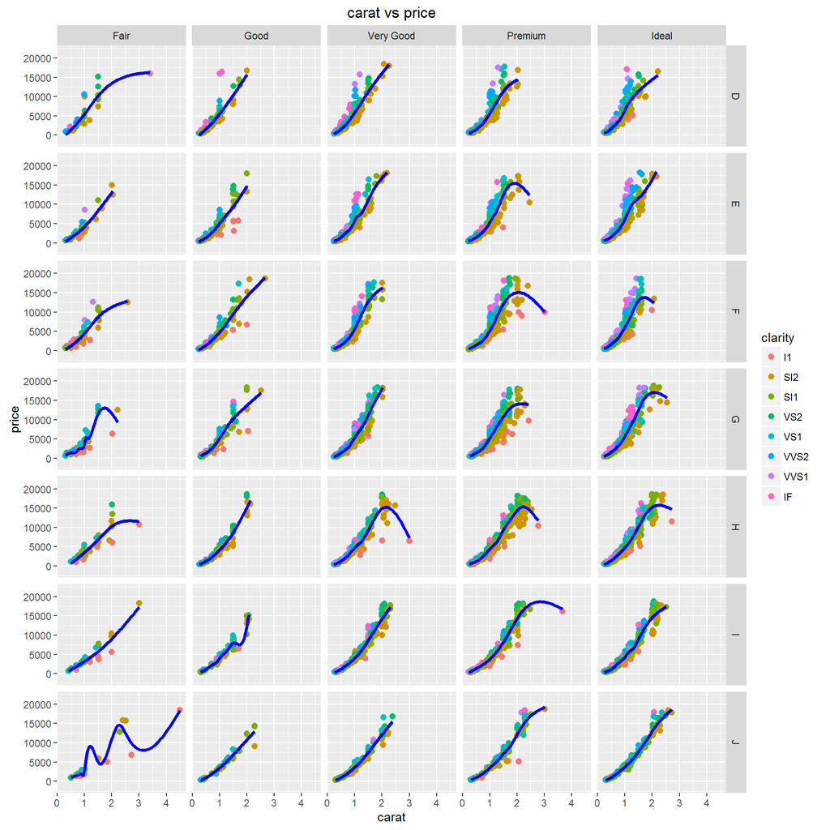